# OTUs vs SVs in the SGG dataset

André Soares

8 January 2018

## 1 - Basic information about each dataset

```r
ps_sv
```

```
## phyloseq-class experiment-level object
## otu_table()   OTU Table:         [ 70937 taxa and 128 samples ]
## sample_data() Sample Data:       [ 128 samples by 80 sample variables ]
## tax_table()   Taxonomy Table:    [ 70937 taxa by 7 taxonomic ranks ]
```

```r
#total numbers of SVs
ntaxa(ps_sv)
```

```
## [1] 70937
```

```r
#total numbers of reads
sum(taxa_sums(ps_sv))
```

```
## [1] 9656492
```

```r
ps_otu
```

```
## phyloseq-class experiment-level object
## otu_table()   OTU Table:         [ 205163 taxa and 128 samples ]
## sample_data() Sample Data:       [ 128 samples by 80 sample variables ]
## tax_table()   Taxonomy Table:    [ 205163 taxa by 7 taxonomic ranks ]
```

```r
#total numbers of OTUs
ntaxa(ps_otu)
```

```
## [1] 205163
```

```r
#total numbers of reads
sum(taxa_sums(ps_otu))
```

```
## [1] 5777207
```

Happy days, both datasets were properly loaded and match the number of taxa advertised.

How many phyla and in what proportions?

```r
sv.phyl<-as.data.frame(table(tax_table(ps_sv)[, "Phylum"], exclude = NULL))
sv.phyl.ord <- sv.phyl[order(-sv.phyl$Freq),]
head(sv.phyl.ord, n=10)
```

```
##                        Var1  Freq
## 60           Proteobacteria 20504
## 54            Parcubacteria 10111
## 53             Omnitrophica  6342
## 78                     <NA>  6288
## 73 Woesearchaeota_(DHVEG-6)  2609
## 11            Bacteroidetes  2574
## 19              Chloroflexi  2476
## 32               Firmicutes  1669
## 4            Actinobacteria  1472
## 49           Microgenomates  1400
```

```r
otu.phyl<-as.data.frame(table(tax_table(ps_otu)[, "Phylum"], exclude = NULL))
otu.phyl.ord <- otu.phyl[order(-otu.phyl$Freq),]
head(otu.phyl.ord, n=10)
```

```
##              Var1  Freq
## 53 Proteobacteria 76824
## 1                 73130
## 46            OP3 14561
## 43            OD1  7729
## 15    Chloroflexi  4383
## 7   Bacteroidetes  3523
## 4  Actinobacteria  2054
## 40    Nitrospirae  1968
## 18  Elusimicrobia  1963
## 51 Planctomycetes  1898
```

Seems OTUs have less taxonomic resolution, ~35% of OTUs weren’t classified to phylum level as compared to ~8.8% with SVs.

Before proceeding, some quick alterations to the dataset, to make downstream analyses easier:

```r
#now without Controls and Taffs Well PUMPED
ps_sv.a = subset_samples(ps_sv, Site.name != "Taffs Well PUMPED")
ps_sv.b = subset_samples(ps_sv.a, Sample_type != "Control")
#making sure no 'empty' taxa are left
ps_sv.b <- prune_taxa(taxa_sums(ps_sv.b) > 0, ps_sv.b)
#order months
sample_data(ps_sv.b)$Month = factor(sample_data(ps_sv.b)$Month,
                                         levels = c("April","August","December"))
#to relative abundances
ps_sv.b.r <-  transform_sample_counts(ps_sv.b, function(x) {x/sum(x)})

#now for the OTUs
#now without Controls and Taffs Well PUMPED
ps_otu.a = subset_samples(ps_otu, Site.name != "Taffs Well PUMPED")
ps_otu.b = subset_samples(ps_otu.a, Sample_type != "Control")
#making sure no 'empty' taxa are left
ps_otu.b <- prune_taxa(taxa_sums(ps_otu.b) > 0, ps_otu.b)
#order months
sample_data(ps_otu.b)$Month = factor(sample_data(ps_otu.b)$Month,
                                         levels = c("April","August","December"))
#to relative abundances
ps_otu.b.r <-  transform_sample_counts(ps_otu.b, function(x) {x/sum(x)})
```

## 2 - General phylum-level taxonomy

```r
# agglomerate taxa
#DON'T FORGET NArm = FALSE
ps_sv.b.r.glom <- tax_glom(ps_sv.b.r, taxrank = 'Phylum',NArm = FALSE)
# create dataframe from phyloseq object
ps_sv.b.r.glom.ps_svdf <- data.table(psmelt(ps_sv.b.r.glom))
# convert Phylum to a character vector from a factor because R
ps_sv.b.r.glom.ps_svdf$Phylum <- as.character(ps_sv.b.r.glom.ps_svdf$Phylum)
# group dataframe by Phylum, calculate median rel. abundance
ps_sv.b.r.glom.ps_svdf[, median := median(Abundance, na.rm = TRUE),
    by = "Phylum"]
# Change name to remainder of Phylum less than 1%
ps_sv.b.r.glom.ps_svdf[(median <= 0.01), Phylum := "Other"]

ps_sv.b.r.glom.ps_svdf.noProteo<-ps_sv.b.r.glom.ps_svdf[!grepl("Proteobacteria", ps_sv.b.r.glom.ps_svdf$Phylum),]
#New table, with Proteobacterial classes only
ps_sv.b.r.ProtCl = subset_taxa(ps_sv.b.r, Phylum == "Proteobacteria")
ps_sv.b.r.ProtCl.glom <- tax_glom(ps_sv.b.r.ProtCl, taxrank = 'Class')
# create dataframe from phyloseq object
ps_sv.b.r.ProtCl.glom.ps_svdf <- data.table(psmelt(ps_sv.b.r.ProtCl.glom))
# convert Class to a character vector from a factor because R
ps_sv.b.r.ProtCl.glom.ps_svdf$Class <- as.character(ps_sv.b.r.ProtCl.glom.ps_svdf$Class)
# group dataframe by Phylum, calculate median rel. abundance
ps_sv.b.r.ProtCl.glom.ps_svdf[, median := median(Abundance, na.rm = TRUE),
                 by = "Class"]
# Change name to remainder of Phylum less than 1%
ps_sv.b.r.ProtCl.glom.ps_svdf[(median <= 0.01), Class := "Other Proteobacteria"]
#join the two data frames
ps_sv.b.r.ProtCl.glom.ps_svdf.noP <- subset(ps_sv.b.r.ProtCl.glom.ps_svdf, select = -Phylum)
#same name= allows merging
names(ps_sv.b.r.glom.ps_svdf.noProteo)[names(ps_sv.b.r.glom.ps_svdf.noProteo) == 'Phylum'] <- 'Taxa'
names(ps_sv.b.r.ProtCl.glom.ps_svdf.noP)[names(ps_sv.b.r.ProtCl.glom.ps_svdf.noP) == 'Class'] <- 'Taxa'
#join the two
ps_sv.b.r.ProteoCl.AllPhy <- rbind(ps_sv.b.r.glom.ps_svdf.noProteo, ps_sv.b.r.ProtCl.glom.ps_svdf.noP)

ps_sv.b.r.ProteoCl.AllPhy.plot<-ggplot(ps_sv.b.r.ProteoCl.AllPhy[Abundance > 0],
                              aes(x = Site.name, y = Abundance/3, fill = Taxa)) +
  facet_grid(Month~.) +
  geom_bar(stat = "identity") +
  theme(axis.title.x = element_blank(),
        axis.text.x = element_text(angle = 45, hjust = 1)) +
  guides(fill = guide_legend(keywidth = 1, keyheight = 1)) +
  ggtitle("SVs") +
  ylab("Relative Abundance\n")
#totals vary because the bars = medians

#Same thing for OTUs
ps_otu.b.r.glom <- tax_glom(ps_otu.b.r, taxrank = 'Phylum',NArm = FALSE)
ps_otu.b.r.glom.ps_otudf <- data.table(psmelt(ps_otu.b.r.glom))
ps_otu.b.r.glom.ps_otudf$Phylum <- as.character(ps_otu.b.r.glom.ps_otudf$Phylum)
ps_otu.b.r.glom.ps_otudf[, median := median(Abundance, na.rm = TRUE),
    by = "Phylum"]
ps_otu.b.r.glom.ps_otudf[(median <= 0.01), Phylum := "Other"]
ps_otu.b.r.glom.ps_otudf.noProteo<-ps_otu.b.r.glom.ps_otudf[!grepl("Proteobacteria", ps_otu.b.r.glom.ps_otudf$Phylum),]
ps_otu.b.r.ProtCl = subset_taxa(ps_otu.b.r, Phylum == "Proteobacteria")
ps_otu.b.r.ProtCl.glom <- tax_glom(ps_otu.b.r.ProtCl, taxrank = 'Class')
ps_otu.b.r.ProtCl.glom.ps_otudf <- data.table(psmelt(ps_otu.b.r.ProtCl.glom))
ps_otu.b.r.ProtCl.glom.ps_otudf$Class <- as.character(ps_otu.b.r.ProtCl.glom.ps_otudf$Class)
ps_otu.b.r.ProtCl.glom.ps_otudf[, median := median(Abundance, na.rm = TRUE),
                 by = "Class"]
ps_otu.b.r.ProtCl.glom.ps_otudf[(median <= 0.01), Class := "Other Proteobacteria"]
ps_otu.b.r.ProtCl.glom.ps_otudf.noP <- subset(ps_otu.b.r.ProtCl.glom.ps_otudf, select = -Phylum)
names(ps_otu.b.r.glom.ps_otudf.noProteo)[names(ps_otu.b.r.glom.ps_otudf.noProteo) == 'Phylum'] <- 'Taxa'
names(ps_otu.b.r.ProtCl.glom.ps_otudf.noP)[names(ps_otu.b.r.ProtCl.glom.ps_otudf.noP) == 'Class'] <- 'Taxa'
ps_otu.b.r.ProteoCl.AllPhy <- rbind(ps_otu.b.r.glom.ps_otudf.noProteo, ps_otu.b.r.ProtCl.glom.ps_otudf.noP)
ps_otu.b.r.ProteoCl.AllPhy.plot<-ggplot(ps_otu.b.r.ProteoCl.AllPhy[Abundance > 0],
                              aes(x = Site.name, y = Abundance/3, fill = Taxa)) +
  facet_grid(Month~.) +
  geom_bar(stat = "identity") +
  theme(axis.title.x = element_blank(),
        axis.text.x = element_text(angle = 45, hjust = 1)) +
  guides(fill = guide_legend(keywidth = 1, keyheight = 1)) +
  ggtitle("OTUs") +
  ylab("Relative Abundance\n")

ps_otu_sv_phyla_profiles<-plot_grid(ps_sv.b.r.ProteoCl.AllPhy.plot, ps_otu.b.r.ProteoCl.AllPhy.plot,
                             ncol = 1, align = 'v')
```

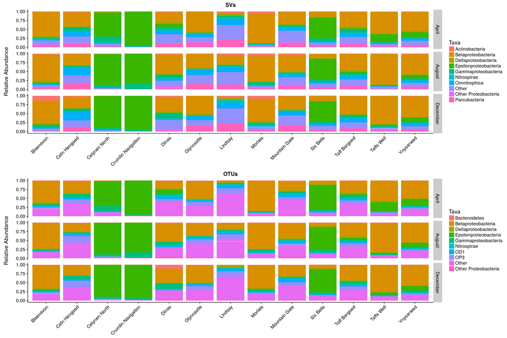

```r
ps_otu_sv_phyla_profiles
```

Basically the same crap!

## 3 - Genus-level trends

```r
ps_sv.b.r.HelicobGall = subset_taxa(ps_sv.b.r, Family=="Helicobacteraceae" | Family=="Gallionellaceae")
ps_sv.b.r.HelicobGall.glom <- tax_glom(ps_sv.b.r.HelicobGall, taxrank = 'Genus')
ps_sv.b.r.HelicobGall.glom.ps_svdf <- data.table(psmelt(ps_sv.b.r.HelicobGall.glom))
ps_sv.b.r.HelicobGall.glom.ps_svdf$Genus <- as.character(ps_sv.b.r.HelicobGall.glom.ps_svdf$Genus)
ps_sv.b.r.HelicobGall.glom.ps_svdf.plot<-ggplot(ps_sv.b.r.HelicobGall.glom.ps_svdf,
                                         aes(x=Genus,y=Abundance,fill=Genus)) +
  geom_point(aes(color=Genus, fill=Genus,
                 size=Abundance)) +
  facet_grid(Month~Site.name)+
  theme(axis.title.x = element_blank(),
        axis.text.x = element_blank(),
        axis.ticks.x = element_blank())
```

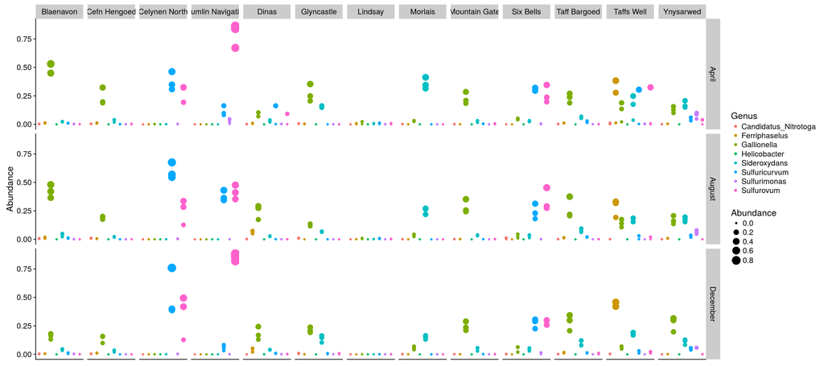

```r
ps_sv.b.r.HelicobGall.glom.ps_svdf.plot
```

In the SV dataset, genera Gallionella, Sideroxydans, Ferriphaselus (Gallionellaceae) and genera Sulfuricurvum Sulfurimonas and Sulfurovum (Campylobacterales) explain most of the Betaproteobacteria and Epsilonproteobacteria dominance across the dataset.

Now for OTUs, check how much diversity is within family Gallionellaceae and if Gallionella and Sideroxydans can be detected.

```r
ps_otu.b.gallionelac = subset_taxa(ps_otu.b.r, Family=="Gallionellaceae")
ps_otu.b.gallionelac.plot<-plot_bar(ps_otu.b.gallionelac,
                                fill="Genus", facet_grid=~Month, x="Site.name") +
  geom_bar(aes(color=Genus, fill=Genus),
           stat="identity", position="stack")
```

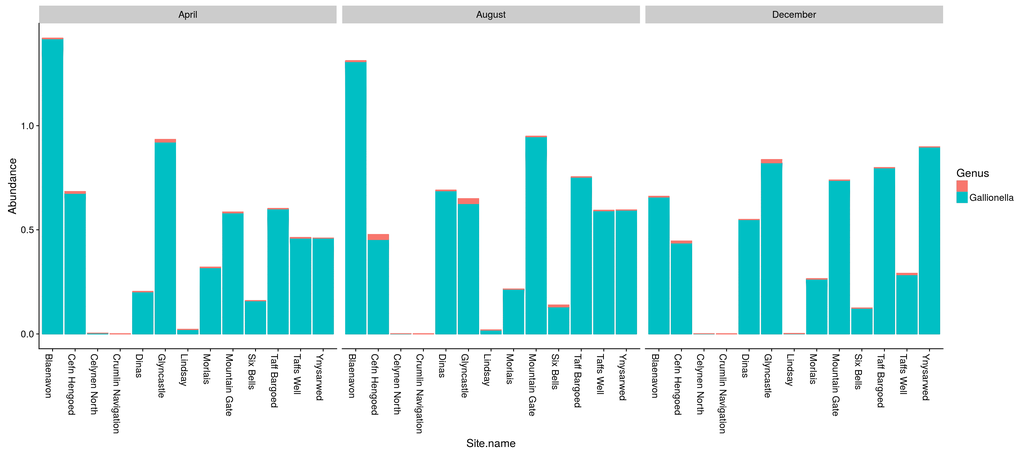

```r
ps_otu.b.gallionelac.plot
```

Less genera detected, and most importantly, Gallionella comes out as the major player in defining Betaproteobacterial dominances in the dataset.

```r
ps_otu.b.campylobac = subset_taxa(ps_otu.b.r, Family=="Helicobacteraceae")
ps_otu.b.campylobac.plot<-plot_bar(ps_otu.b.campylobac,
                                fill="Genus", facet_grid=~Month, x="Site.name") +
  geom_bar(aes(color=Genus, fill=Genus),
           stat="identity", position="stack")
```

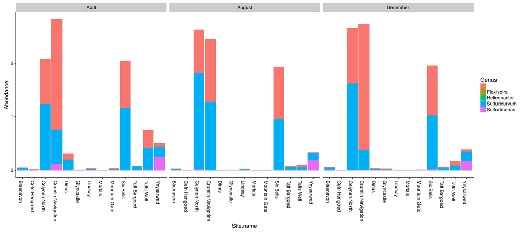

```r
ps_otu.b.campylobac.plot
```

```r
ps_otu.b.r.HelicobGall = subset_taxa(ps_otu.b.r, Family=="Helicobacteraceae" | Family=="Gallionellaceae")
ps_otu.b.r.HelicobGall.glom <- tax_glom(ps_otu.b.r.HelicobGall, taxrank = 'Genus', NArm = FALSE)
ps_otu.b.r.HelicobGall.glom.ps_otudf_otu <- data.table(psmelt(ps_otu.b.r.HelicobGall.glom))
ps_otu.b.r.HelicobGall.glom.ps_otudf_otu$Genus <- as.character(ps_otu.b.r.HelicobGall.glom.ps_otudf_otu$Genus)
ps_otu.b.r.HelicobGall.glom.ps_otudf_otu.plot<-ggplot(ps_otu.b.r.HelicobGall.glom.ps_otudf_otu[Abundance > 0],
                                          aes(x=Genus,y=Abundance,fill=Genus)) +
  geom_point(aes(color=Genus, fill=Genus,
                 size=Abundance)) +
  facet_grid(Month~Site.name)+
  theme(axis.title.x = element_blank(),
        axis.text.x = element_blank(),
        axis.ticks.x = element_blank())
```

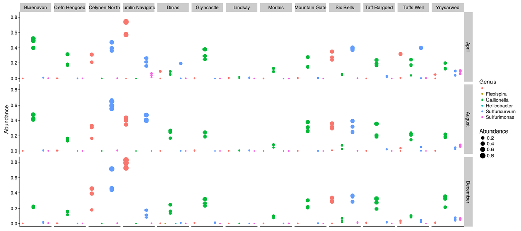

```r
ps_otu.b.r.HelicobGall.glom.ps_otudf_otu.plot
```

In the OTU dataset, however, less taxonomic resolution means the abovementioned genera can’t be discerned as they are in the SV dataset. Within family Gallionellaceae, only genus Gallionella is present.

## 4 - Ordination time!

```r
# Calculate ordination
ps_sv.b.r.pcoa  <- ordinate(ps_sv.b.r, "PCoA", distance="jsd",
                         k=3, trymax=1e3, weighted=TRUE)
evals_sv<-ps_sv.b.r.pcoa$values$Eigenvalues
#Axis 1 and 2
pcoa.a12_sv<-sum(evals_sv[1:2])/sum(evals_sv)
pcoa.a12.r_sv<-round(pcoa.a12_sv, digits=4)*100
#Axis 1 and 3
pcoa.a13_sv<-sum(evals_sv[c(1,3)])/sum(evals_sv)
pcoa.a13.r_sv<-round(pcoa.a13_sv, digits=4)*100

ps_sv.b.r.pcoa.plot.a1 <- plot_ordination(ps_sv.b.r, ps_sv.b.r.pcoa, axes = c(1,2),
                                       color="Site.name", shape="Month") +
  geom_polygon(aes(fill=Site.name), alpha=0.5) +
  geom_point(alpha=0.5, size=5)+
  scale_alpha(guide = 'none') +
  theme(legend.position = "none") +
  annotate("text", y= 0.3, x =0.25,label=paste("Axes 1 and 2:\n",pcoa.a12.r_sv,"% variation")
           ,hjust=0.5, size=5)

ps_sv.b.r.pcoa.plot.a2 <- plot_ordination(ps_sv.b.r, ps_sv.b.r.pcoa, axes = c(1,3),
                                       color="Site.name", shape="Month")+
  geom_polygon(aes(fill=Site.name), alpha=0.5) +
  geom_point(alpha=0.5, size=5) +
  scale_alpha(guide = 'none')+
  annotate("text", y= 0.2, x =0.25,label=paste("Axes 1 and 3:\n",pcoa.a13.r_sv,"% variation")
           ,hjust=0.5, size=5)

ps_sv.b.r.pcoa.plot<-plot_grid(ps_sv.b.r.pcoa.plot.a1, ps_sv.b.r.pcoa.plot.a2,
                            labels=c("A","B"))

# OTUs now
ps_otu.b.r.pcoa  <- ordinate(ps_otu.b.r, "PCoA", distance="jsd",
                         k=3, trymax=1e3, weighted=TRUE)
evals_otu<-ps_otu.b.r.pcoa$values$Eigenvalues
#Axis 1 and 2
pcoa.a12_otu<-sum(evals_otu[1:2])/sum(evals_otu)
pcoa.a12.r_otu<-round(pcoa.a12_otu, digits=4)*100
#Axis 1 and 3
pcoa.a13_otu<-sum(evals_otu[c(1,3)])/sum(evals_otu)
pcoa.a13.r_otu<-round(pcoa.a13_otu, digits=4)*100
ps_otu.b.r.pcoa.plot.a1 <- plot_ordination(ps_otu.b.r, ps_otu.b.r.pcoa, axes = c(1,2),
                                       color="Site.name", shape="Month") +
  geom_polygon(aes(fill=Site.name), alpha=0.5) +
  geom_point(alpha=0.5, size=5)+
  scale_alpha(guide = 'none') +
  theme(legend.position = "none") +
  annotate("text", y= 0.3, x =-0.25,label=paste("Axes 1 and 2:\n",pcoa.a12.r_otu,"% variation")
           ,hjust=0.5, size=5)
ps_otu.b.r.pcoa.plot.a2 <- plot_ordination(ps_otu.b.r, ps_otu.b.r.pcoa, axes = c(1,3),
                                       color="Site.name", shape="Month")+
  geom_polygon(aes(fill=Site.name), alpha=0.5) +
  geom_point(alpha=0.5, size=5) +
  scale_alpha(guide = 'none')+
  annotate("text", y= 0.15, x =-0.25,label=paste("Axes 1 and 3:\n",pcoa.a13.r_otu,"% variation")
           ,hjust=0.5, size=5)

ps_otu.b.r.pcoa.plot<-plot_grid(ps_otu.b.r.pcoa.plot.a1, ps_otu.b.r.pcoa.plot.a2,
                            labels=c("A","B"))
```

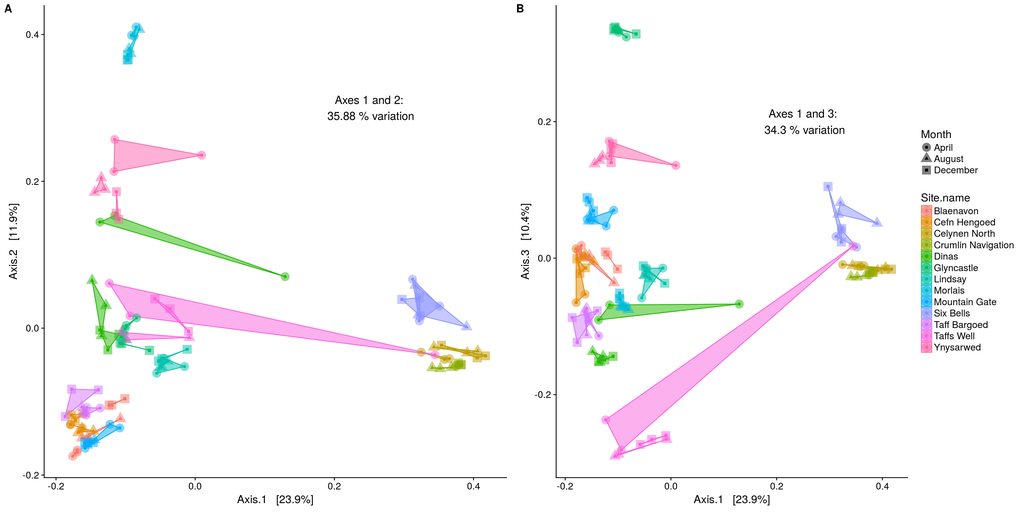

```r
ps_sv.b.r.pcoa.plot
```

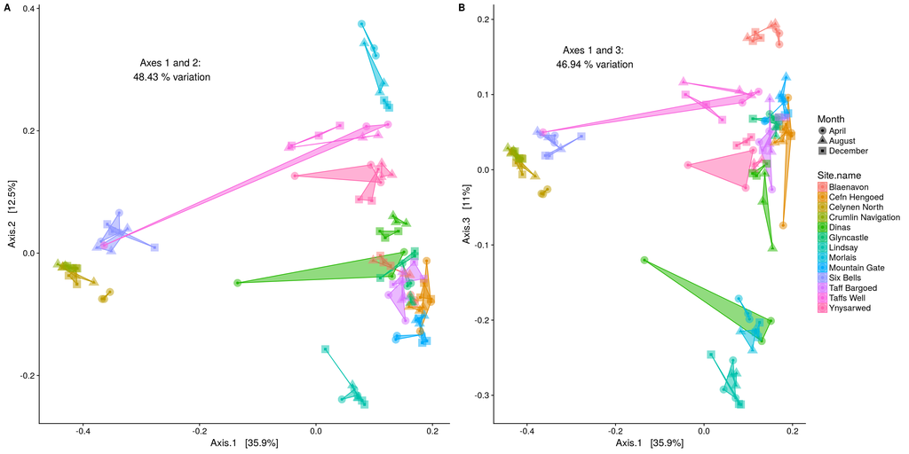

```r
ps_otu.b.r.pcoa.plot
```

With OTUs, more variation is explained by the first two axes of the PCoA - 48.43% as opposed to 35.88% with SVs.